# Trial/participant exclusion

[Guillermo Montero-Melis](https://www.mpi.nl/people/montero-melis-guillermo)

2021-10-26

# 1 Introduction

This report applies the second exclusion criterion indicated in our Registered Report (https://osf.io/26fbh/, p.22) and documents the results:

> 1. We will exclude trials in which the participant starts the oral recall before the beep, that is, if the word onset falls before the end of the 6 second memory phase (see Figure 1).
> 2. In the two interference conditions, we will exclude trials in which participants fail to execute the interference task, which we define as starting the paradiddle later than 3 seconds into the memory phase (that is, if the first tap is registered later than 3 seconds after the offset of the fourth word in the trial).

> At the participant level, we will exclude participants for whom either of the above criteria or technical failure (e.g., recording not working) result in excluding more than 30% of the trials across blocks or more than 50% of trials in a single block. All exclusions will take place before the recall data is coded and analysed.

A list of to-be-excluded trials is saved to disk to be read by data processing scripts before analysis.

# 2 Session set up

Libraries:

```r
library("knitr")
library("tidyverse")
theme_set(theme_bw())  # ggplot theme
knitr::opts_chunk$set(fig.height=4)
```

Source file where functions are defined:

```r
source("myfunctions/paradiddle_fncs.R")
```

# 3 An example first

Extract tapping information from one participant’s log file:

```r
log_ex <- extract_tap_info("../data/raw_data/1_sp13_replication_swe_2020_Oct_30_1334.log")
```

Plot taps for this participant. For the first practice trials there should be no tapping, so this plot should be empty:

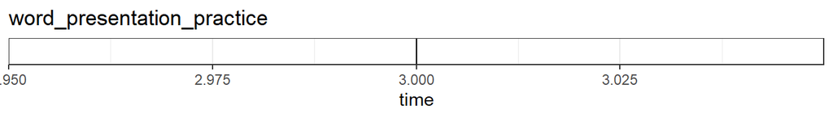

```r
plot_taps(log_ex, "word_presentation_practice")
```

Block-specific training trials:

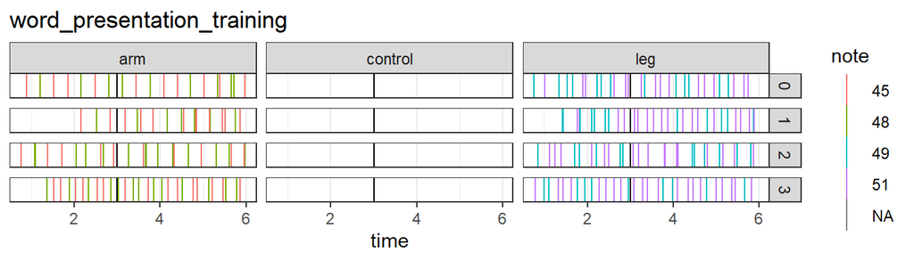

```r
plot_taps(log_ex, "word_presentation_training")
```

Real trials:

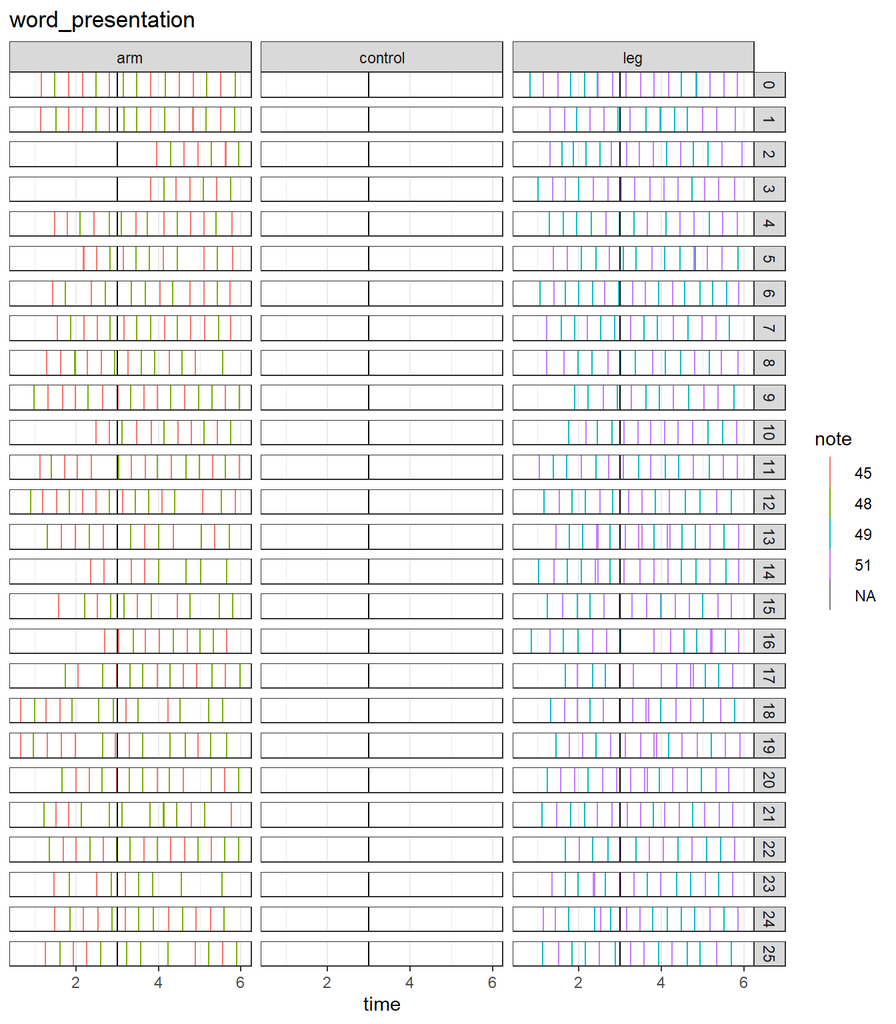

```r
plot_taps(log_ex, "word_presentation")
```

For exclusion, we *only* care about whether they started the paradiddle before 3 seconds of the memory period had ellapsed. In this case, for instance, trials 2 and 3 from the arm block will have to be excluded.

The following function computes this; we show only the 6 first trials of the arm block (block 2):

```r
compute_valid(log_ex) %>% head(6) %>% kable(digits = 3)
```

| routine | block | trial | time_exp | time | note | pad | condition | ppt_file | valid |
| --- | --- | --- | --- | --- | --- | --- | --- | --- | --- |
| word_presentation | 2 | 0 | 3357.305 | 1.169 | 45 | SamplePad 1 | arm | ../data/raw_data/1_sp13_replication_swe_2020_Oct_30_1334.log | 1 |
| word_presentation | 2 | 1 | 3375.969 | 1.152 | 45 | SamplePad 1 | arm | ../data/raw_data/1_sp13_replication_swe_2020_Oct_30_1334.log | 1 |
| word_presentation | 2 | 2 | 3400.994 | 3.962 | 45 | SamplePad 1 | arm | ../data/raw_data/1_sp13_replication_swe_2020_Oct_30_1334.log | 0 |
| word_presentation | 2 | 3 | 3419.041 | 3.810 | 45 | SamplePad 1 | arm | ../data/raw_data/1_sp13_replication_swe_2020_Oct_30_1334.log | 0 |
| word_presentation | 2 | 4 | 3435.677 | 1.481 | 45 | SamplePad 1 | arm | ../data/raw_data/1_sp13_replication_swe_2020_Oct_30_1334.log | 1 |
| word_presentation | 2 | 5 | 3455.696 | 2.185 | 45 | SamplePad 1 | arm | ../data/raw_data/1_sp13_replication_swe_2020_Oct_30_1334.log | 1 |

# 4 Compute valid/invalid trials for all participants

Make a list of all valid participant files:

```r
# save the name of all log files into vector
path <- "../data/raw_data/"
logfiles <- list.files(path, pattern = ".*\\.log")  # select .log files

# get the participant ID for each logfile
logfiles_id <- gsub("^(\\d+)_.*", "\\1", logfiles)

# load participant sheet where we've marked who needs to be excluded
ppt_data <- read_csv("../data/participant_data_raw.csv") %>%
  select(1:2)
names(ppt_data)[2] <- "valid"
# select valid participants and extract their ID
ppt_data <- ppt_data %>%
  filter(valid %in% c(1, 2)) %>%  # values of 1 and 2 are valid
  mutate(valid_id = gsub("^(\\d+),.*", "\\1", pptID))  # copy ppt ID to column

# vector of valid participant IDs
valid_ids <- unique(ppt_data$valid_id)

# only keep logfiles of valid participants
logfiles_valid <- logfiles[logfiles_id %in% valid_ids]
# exclude also those that contain "excl" (marked by RA to be excluded)
logfiles_valid <- logfiles_valid[! grepl("excl", logfiles_valid)]
```

For each participant, compute how many trials need to be excluded by block:

```r
# create a dataframe of all trials marking if they need to be excluded or not
ppt_valid_trials <- map(logfiles_valid, function(logf) {
  full_path <- paste0(path, logf)
  extract_tap_info(full_path) %>%
    compute_valid()
  }) %>%
  bind_rows()
# summarize the results by participant
ppt_valid_trials_summary <- compute_valid_summary(ppt_valid_trials)
```

# 5 Apply exclusion criteria

Participant-block combinations with more than 50% invalid trials?

```r
ppt_valid_trials_summary %>%
  filter(prop_invalid > .5)
```

```
## # A tibble: 0 x 6
## # Groups:   ppt_file, block [0]
## # ... with 6 variables: ppt_file <chr>, block <dbl>, condition <chr>,
## #   valid <dbl>, N <int>, prop_invalid <dbl>
```

**No exclusions of entire blocks based on this criterion.**

Participants with more than 30% invalid trials across both critical blocks?

```r
ppt_valid_trials_summary %>%
  group_by(ppt_file) %>%
  summarise(prop_invalid = mean(prop_invalid)) %>%
  filter(prop_invalid > .3)
```

```
## # A tibble: 0 x 2
## # ... with 2 variables: ppt_file <chr>, prop_invalid <dbl>
```

**No exclusions of whole participants based on this criterion either.**

**Conclusion**

Only trial-level exclusion need to be done!

# 6 Save a file to disk with the trials that need to be excluded

```r
# rename columns for compatibility with the data processing script where this
# is going to be used:
excluded_trials <- ppt_valid_trials %>%
  ungroup() %>%
  filter(valid == 0) %>%
  mutate(
    # ID unique is participant number and DateTime as per log file
    ID_unique = gsub(".*ta/(\\d+)_.*_(202\\d.*)\\.log", "\\1_\\2", ppt_file),
    trial_block = trial + 1  # trial_block = 1, ..., 26
  ) %>%
  select(ID_unique, block, trial_block) %>%
  arrange(ID_unique, block, trial_block)
head(excluded_trials)
```

```
## # A tibble: 6 x 3
##   ID_unique           block trial_block
##   <chr>               <dbl>       <dbl>
## 1 1_2020_Oct_30_1334      2           3
## 2 1_2020_Oct_30_1334      2           4
## 3 17_2020_Nov_27_1026     3          13
## 4 19_2021_Apr_23_1500     2           5
## 5 22_2020_Dec_11_0846     1           2
## 6 22_2020_Dec_11_0846     1           8
```

Save to disk:

```r
write_csv(excluded_trials, "../data/excluded_trials_bc_of_paradiddle.csv")
```

# 7 Appendix: complete lists of invalid trials

First a list of invalid trials per participant

```r
ppt_valid_trials_summary %>%
  group_by(ppt_file) %>%
  summarise(prop_invalid = mean(prop_invalid)) %>%
  arrange(-prop_invalid) %>%
  kable(digits = 3)
```

| ppt_file | prop_invalid |
| --- | --- |
| ../data/raw_data/59_sp13_replication_swe_2021_May_19_0836.log | 0.212 |
| ../data/raw_data/64_sp13_replication_swe_2021_May_21_1502.log | 0.154 |
| ../data/raw_data/58_sp13_replication_swe_2021_May_14_1300.log | 0.077 |
| ../data/raw_data/60_sp13_replication_swe_2021_May_19_1031.log | 0.077 |
| ../data/raw_data/55_sp13_replication_swe_2021_Apr_16_1503.log | 0.058 |
| ../data/raw_data/65_sp13_replication_swe_2021_May_26_1033.log | 0.058 |
| ../data/raw_data/1_sp13_replication_swe_2020_Oct_30_1334.log | 0.038 |
| ../data/raw_data/22_sp13_replication_swe_2020_Dec_11_0846.log | 0.038 |
| ../data/raw_data/24_sp13_replication_swe_2020_Dec_11_1332.log | 0.038 |
| ../data/raw_data/39_sp13_replication_swe_2021_Feb_24_1456.log | 0.038 |
| ../data/raw_data/41_sp13_replication_swe_2021_Mar_03_1035.log | 0.038 |
| ../data/raw_data/61_sp13_replication_swe_2021_May_19_1501.log | 0.038 |
| ../data/raw_data/68_sp13_replication_swe_2021_May_28_0841.log | 0.038 |
| ../data/raw_data/74_sp13_replication_swe_2021_Jun_09_1037.log | 0.038 |
| ../data/raw_data/9_sp13_replication_swe_2020_Nov_20_1107.log | 0.038 |
| ../data/raw_data/17_sp13_replication_swe_2020_Nov_27_1026.log | 0.019 |
| ../data/raw_data/19_sp13_replication_swe_2021_Apr_23_1500.log | 0.019 |
| ../data/raw_data/27_sp13_replication_swe_2021_Feb_03_1312.log | 0.019 |
| ../data/raw_data/30_sp13_replication_swe_2021_Feb_05_1508.log | 0.019 |
| ../data/raw_data/31_sp13_replication_swe_2021_Feb_10_1034.log | 0.019 |
| ../data/raw_data/32_sp13_replication_swe_2021_May_05_1032.log | 0.019 |
| ../data/raw_data/34_sp13_replication_swe_2021_Feb_12_1023.log | 0.019 |
| ../data/raw_data/35_sp13_replication_swe_2021_Feb_17_1032.log | 0.019 |
| ../data/raw_data/40_sp13_replication_swe_2021_Mar_03_0838.log | 0.019 |
| ../data/raw_data/49_sp13_replication_swe_2021_Mar_31_1459.log | 0.019 |
| ../data/raw_data/50_sp13_replication_swe_2021_Apr_02_0827.log | 0.019 |
| ../data/raw_data/52_sp13_replication_swe_2021_Apr_09_1311.log | 0.019 |
| ../data/raw_data/62_sp13_replication_swe_2021_May_21_1026.log | 0.019 |
| ../data/raw_data/70_sp13_replication_swe_2021_May_28_1301.log | 0.019 |
| ../data/raw_data/76_sp13_replication_swe_2021_Jun_18_1027.log | 0.019 |
| ../data/raw_data/10_sp13_replication_swe_2020_Nov_13_1104.log | 0.000 |
| ../data/raw_data/11_sp13_replication_swe_2020_Nov_13_1332.log | 0.000 |
| ../data/raw_data/12_sp13_replication_swe_2020_Nov_13_1530.log | 0.000 |
| ../data/raw_data/13_sp13_replication_swe_2020_Nov_20_1331.log | 0.000 |
| ../data/raw_data/14_sp13_replication_swe_2020_Nov_20_1526.log | 0.000 |
| ../data/raw_data/15_sp13_replication_swe_2020_Nov_25_1534.log | 0.000 |
| ../data/raw_data/16_sp13_replication_swe_2020_Nov_27_0830.log | 0.000 |
| ../data/raw_data/18_sp13_replication_swe_2020_Nov_27_1535.log | 0.000 |
| ../data/raw_data/2_sp13_replication_swe_2020_Nov_25_1038.log | 0.000 |
| ../data/raw_data/20_sp13_replication_swe_2020_Dec_04_1519.log | 0.000 |
| ../data/raw_data/21_sp13_replication_swe_2020_Dec_09_1334.log | 0.000 |
| ../data/raw_data/23_sp13_replication_swe_2020_Dec_11_1037.log | 0.000 |
| ../data/raw_data/25_sp13_replication_swe_2020_Dec_16_1532.log | 0.000 |
| ../data/raw_data/26_sp13_replication_swe_2020_Dec_18_1336.log | 0.000 |
| ../data/raw_data/28_sp13_replication_swe_2021_Feb_03_1459.log | 0.000 |
| ../data/raw_data/29_sp13_replication_swe_2021_Feb_05_1034.log | 0.000 |
| ../data/raw_data/3_sp13_replication_swe_2020_Nov_04_1332.log | 0.000 |
| ../data/raw_data/33_sp13_replication_swe_2021_Feb_12_0822.log | 0.000 |
| ../data/raw_data/36_sp13_replication_swe_2021_Feb_19_1027.log | 0.000 |
| ../data/raw_data/37_sp13_replication_swe_2021_Feb_19_1309.log | 0.000 |
| ../data/raw_data/38_sp13_replication_swe_2021_Feb_24_1032.log | 0.000 |
| ../data/raw_data/4_sp13_replication_swe_2020_Nov_04_1532.log | 0.000 |
| ../data/raw_data/42_sp13_replication_swe_2021_Mar_03_1307.log | 0.000 |
| ../data/raw_data/43_sp13_replication_swe_2021_May_05_1303.log | 0.000 |
| ../data/raw_data/44_sp13_replication_swe_2021_Mar_05_0836.log | 0.000 |
| ../data/raw_data/45_sp13_replication_swe_2021_Mar_05_1501.log | 0.000 |
| ../data/raw_data/46_sp13_replication_swe_2021_Mar_10_1030.log | 0.000 |
| ../data/raw_data/47_sp13_replication_swe_2021_Mar_17_1501.log | 0.000 |
| ../data/raw_data/48_sp13_replication_swe_2021_Mar_24_1311.log | 0.000 |
| ../data/raw_data/5_sp13_replication_swe_2020_Nov_06_0835.log | 0.000 |
| ../data/raw_data/51_sp13_replication_swe_2021_Apr_09_0829.log | 0.000 |
| ../data/raw_data/53_sp13_replication_swe_2021_May_12_0839.log | 0.000 |
| ../data/raw_data/54_sp13_replication_swe_2021_May_12_1033.log | 0.000 |
| ../data/raw_data/56_sp13_replication_swe_2021_Apr_21_1031.log | 0.000 |
| ../data/raw_data/57_sp13_replication_swe_2021_May_12_1503.log | 0.000 |
| ../data/raw_data/6_sp13_replication_swe_2020_Nov_11_1018.log | 0.000 |
| ../data/raw_data/63_sp13_replication_swe_2021_May_21_1301.log | 0.000 |
| ../data/raw_data/66_sp13_replication_swe_2021_May_26_1302.log | 0.000 |
| ../data/raw_data/67_sp13_replication_swe_2021_May_26_1503.log | 0.000 |
| ../data/raw_data/69_sp13_replication_swe_2021_May_28_1031.log | 0.000 |
| ../data/raw_data/7_sp13_replication_swe_2020_Nov_11_1306.log | 0.000 |
| ../data/raw_data/71_sp13_replication_swe_2021_Jun_02_1500.log | 0.000 |
| ../data/raw_data/72_sp13_replication_swe_2021_Jun_04_0833.log | 0.000 |
| ../data/raw_data/73_sp13_replication_swe_2021_Jun_04_1319.log | 0.000 |
| ../data/raw_data/75_sp13_replication_swe_2021_Jun_09_1502.log | 0.000 |
| ../data/raw_data/8_sp13_replication_swe_2020_Nov_11_1630.log | 0.000 |
| ../data/raw_data/9_sp13_replication_swe_2020_Nov_13_0848.log | 0.000 |

Next a list of invalid trials per participant-block

```r
ppt_valid_trials_summary %>%
  arrange(- prop_invalid) %>%
  kable(digits = 3)
```

| ppt_file | block | condition | valid | N | prop_invalid |
| --- | --- | --- | --- | --- | --- |
| ../data/raw_data/59_sp13_replication_swe_2021_May_19_0836.log | 3 | arm | 18 | 26 | 0.308 |
| ../data/raw_data/64_sp13_replication_swe_2021_May_21_1502.log | 3 | arm | 18 | 26 | 0.308 |
| ../data/raw_data/58_sp13_replication_swe_2021_May_14_1300.log | 1 | arm | 22 | 26 | 0.154 |
| ../data/raw_data/60_sp13_replication_swe_2021_May_19_1031.log | 1 | leg | 22 | 26 | 0.154 |
| ../data/raw_data/55_sp13_replication_swe_2021_Apr_16_1503.log | 3 | arm | 23 | 26 | 0.115 |
| ../data/raw_data/59_sp13_replication_swe_2021_May_19_0836.log | 2 | leg | 23 | 26 | 0.115 |
| ../data/raw_data/65_sp13_replication_swe_2021_May_26_1033.log | 2 | leg | 23 | 26 | 0.115 |
| ../data/raw_data/1_sp13_replication_swe_2020_Oct_30_1334.log | 2 | arm | 24 | 26 | 0.077 |
| ../data/raw_data/22_sp13_replication_swe_2020_Dec_11_0846.log | 1 | leg | 24 | 26 | 0.077 |
| ../data/raw_data/24_sp13_replication_swe_2020_Dec_11_1332.log | 1 | arm | 24 | 26 | 0.077 |
| ../data/raw_data/39_sp13_replication_swe_2021_Feb_24_1456.log | 2 | leg | 24 | 26 | 0.077 |
| ../data/raw_data/61_sp13_replication_swe_2021_May_19_1501.log | 1 | leg | 24 | 26 | 0.077 |
| ../data/raw_data/68_sp13_replication_swe_2021_May_28_0841.log | 2 | arm | 24 | 26 | 0.077 |
| ../data/raw_data/17_sp13_replication_swe_2020_Nov_27_1026.log | 3 | arm | 25 | 26 | 0.038 |
| ../data/raw_data/19_sp13_replication_swe_2021_Apr_23_1500.log | 2 | arm | 25 | 26 | 0.038 |
| ../data/raw_data/27_sp13_replication_swe_2021_Feb_03_1312.log | 2 | leg | 25 | 26 | 0.038 |
| ../data/raw_data/30_sp13_replication_swe_2021_Feb_05_1508.log | 1 | arm | 25 | 26 | 0.038 |
| ../data/raw_data/31_sp13_replication_swe_2021_Feb_10_1034.log | 1 | leg | 25 | 26 | 0.038 |
| ../data/raw_data/32_sp13_replication_swe_2021_May_05_1032.log | 1 | leg | 25 | 26 | 0.038 |
| ../data/raw_data/34_sp13_replication_swe_2021_Feb_12_1023.log | 1 | arm | 25 | 26 | 0.038 |
| ../data/raw_data/35_sp13_replication_swe_2021_Feb_17_1032.log | 1 | arm | 25 | 26 | 0.038 |
| ../data/raw_data/40_sp13_replication_swe_2021_Mar_03_0838.log | 1 | leg | 25 | 26 | 0.038 |
| ../data/raw_data/41_sp13_replication_swe_2021_Mar_03_1035.log | 1 | arm | 25 | 26 | 0.038 |
| ../data/raw_data/41_sp13_replication_swe_2021_Mar_03_1035.log | 2 | leg | 25 | 26 | 0.038 |
| ../data/raw_data/49_sp13_replication_swe_2021_Mar_31_1459.log | 1 | arm | 25 | 26 | 0.038 |
| ../data/raw_data/50_sp13_replication_swe_2021_Apr_02_0827.log | 2 | arm | 25 | 26 | 0.038 |
| ../data/raw_data/52_sp13_replication_swe_2021_Apr_09_1311.log | 1 | arm | 25 | 26 | 0.038 |
| ../data/raw_data/62_sp13_replication_swe_2021_May_21_1026.log | 1 | arm | 25 | 26 | 0.038 |
| ../data/raw_data/70_sp13_replication_swe_2021_May_28_1301.log | 1 | arm | 25 | 26 | 0.038 |
| ../data/raw_data/74_sp13_replication_swe_2021_Jun_09_1037.log | 2 | arm | 25 | 26 | 0.038 |

[output cut: 124 more lines]